# مقارنة بين أدوات التجذيع الحاسوبية في اللّغة العربية

في هذه التجربة نقارن بين بعض أدوات التجذيع المستخدمة للّغة العربية.

مبدئياً ما هو التجذيع؟

التجذيع هو عملية إزالة السوابق و اللواحق للحصول علي جذع مشترك بين الكلمات, يعتبر التجذيع وسيلة للحد من عدد الكلمات و الحصول علي الكلمات المتقاربة في حالة البحث.

فمثلا من الطبيعي أنه إذا بحثنا عن كلمة "الكتابات" نجد نتائج تشمل "الكتابة"

أما عن السوابق فهي الاجزاء التي تتصل لأول الكلمات و ليست جزء أصيل منها, مثل "ي" المضارعة في الأفعال, و مثل "ال" التعريف. و مثلها اللواحق و هي التي تلحق بالكلمة أي تلتصق بآخرها و ليست أصيلة فيها مثل "ات" التأنيث و غيرها.

السوابق و اللّواحق يشار إليهما باللّواصق.

يذكر أيضا, أن هناك لواصق بسيطة و هي التي تتكون من صورة واحدة من اللّواصق مثل في "الباب", و هناك لواصق معقّدة تتكون من أكثر من صورة مثل "بالباب", فههنا الباء و "ال" التعريف.

اعلم أن التجذيع وظيفة مختلفة عن التجذير و هو الوصول لأصل الكلمة الصرفي.

فكلمة "الكتابات" و "الكتابة" و "يكتب" و "سيكتب" كلهم ينتمون **لنفس** الجذر "كتب", لكن تنتمي الكلمتان الأولتان لنفس الجذع "كتاب" و الأخرتان للجذع "كتب".

في البحث نناقش:

1. طريقة الاستخدام

2. الكفاءة

3. السرعة

```python
from style import style
style.css()
```

```python
import matplotlib.pyplot as plt
import re
import elements
import string
import emoji
import nltk
nltk.download("stopwords")
```

```
True
```

## البيانات

### قراءة البيانات

مصدر الحزمة: https://github.com/motazsaad/arabic-sentiment-analysis

```python
import numpy as np
import pandas as pd
```

```python
pd.options.display.max_colwidth = 100
```

```python
path = '../arabic-sentiment-analysis-master/arabic_tweets_txt/'
```

```python
data = pd.read_csv(f'{path}/positive_tweets_arabic_20181206_1k.txt',sep='\t',names=['tweet'])
```

```python
len(data)
```

```
21428
```

```python
raw_txt = data.iloc[300].tweet
raw_txt
```

```
'- ما يهمني أستمرار الأشياء للأبد يكفي أني كنت مبسوطه لحظتها لأنه وبك ُ ل عقلانيه مافيه شيء يدوم للأبد ! . 👏 💕'
```

## المعالجات القبلية

نقوم بتحميل بتحميل مسبعدات الفهرسة من مكتبةNLTK.

```python
arb_stopwords = set(nltk.corpus.stopwords.words("arabic"))
```

تقوم الدوالّ التالية بإزالة التشكيل و التطويل و مستبعدات الفهرسة و المسافات المتتالية و المسافات أول الجمل و تحول التفاعلات (إيموجي) لأوصاف مكتوبة.

```python
def tashkel_removal(t):
    return t.translate(t.maketrans('',"",''.join(elements.DIACRITICS)))
```

```python
def tatweel_removal(t):
    return re.sub('ـ+', '',t)
```

```python
def normalization(t):
    return t.translate(t.maketrans(''.join(elements.ALEF_HAMZA_FORMS+elements.NON_ALIF_HAMZA_FORMS),"اااوي"))
```

```python
def stopwords_removal(t,stop=arb_stopwords):
    return ' '.join([word for word in t.split() if word not in stop])
```

```python
def successive_space_removal(t):
    t=t.strip()
    return re.sub(' +', ' ',t)
```

```python
def punctuation_removal(t):
    return t.translate(t.maketrans('',"",''.join(elements.PUNCTUATION_MARKS[:-1])+'?'))
```

```python
def emojify(t):
    return emoji.demojize(t)
```

نقوم بترتيب سلسلة الدوالّ للمعالجة القبلية, تغيير الترتيب قد يؤدي إلي نواتج مختلفة.

```python
pipeline = [stopwords_removal,tashkel_removal,tatweel_removal,punctuation_removal,
        normalization,emojify,successive_space_removal]
```

```python
pipeline_stages = str('stopwords_removal,tashkel_removal,tatweel_removal,punctuation_removal,normalization,emojify,successive_space_removal').split(',')
```

نقوم بحفظ النص دون معالجة قبلية

```python
prep_txt = raw_txt
```

```python
prep_txt
```

```
'- ما يهمني أستمرار الأشياء للأبد يكفي أني كنت مبسوطه لحظتها لأنه وبك ُ ل عقلانيه مافيه شيء يدوم للأبد ! . 👏 💕'
```

مراحل التغيير بعد كل دالّة

```python
for method,name in zip(pipeline,pipeline_stages):
    prep_txt= method(prep_txt)
    print(name,'-->',prep_txt)
```

```
stopwords_removal --> - يهمني أستمرار الأشياء للأبد يكفي أني كنت مبسوطه لحظتها لأنه وبك ُ ل عقلانيه مافيه شيء يدوم للأبد ! . 👏 💕
tashkel_removal --> - يهمني أستمرار الأشياء للأبد يكفي أني كنت مبسوطه لحظتها لأنه وبك  ل عقلانيه مافيه شيء يدوم للأبد ! . 👏 💕
tatweel_removal --> - يهمني أستمرار الأشياء للأبد يكفي أني كنت مبسوطه لحظتها لأنه وبك  ل عقلانيه مافيه شيء يدوم للأبد ! . 👏 💕
punctuation_removal -->  يهمني أستمرار الأشياء للأبد يكفي أني كنت مبسوطه لحظتها لأنه وبك  ل عقلانيه مافيه شيء يدوم للأبد   👏 💕
normalization -->  يهمني استمرار الاشياء للابد يكفي اني كنت مبسوطه لحظتها لانه وبك  ل عقلانيه مافيه شيء يدوم للابد   👏 💕
emojify -->  يهمني استمرار الاشياء للابد يكفي اني كنت مبسوطه لحظتها لانه وبك  ل عقلانيه مافيه شيء يدوم للابد   :clapping_hands: :two_hearts:
successive_space_removal --> يهمني استمرار الاشياء للابد يكفي اني كنت مبسوطه لحظتها لانه وبك ل عقلانيه مافيه شيء يدوم للابد :clapping_hands: :two_hearts:
```

لاحظ أهمية المعالجة القبلية المخصوصة علي حسب طبيعة كل حزمة, فعلي سبيل المثال النصوص من منصة تويتر مختلفة عن النصوص من الكتب مختلفة عن المدونات.

## أدوات التجذيع

تجربة مبدئية لكيفية عمل كل أداة تجذيع, مع تقييم لجودة العملية.

تعمل المكتبات علي مستويين علي حسب طبيعة كل أداة, الطريقة الأولي هي التجذيع علي مستوي النص, و الثانية علي مستوي الكلمة في النص.

بالتالي سنقوم باختبار كل مجذّع علي أربعة أحوال:

1. النص المعالج

2. النص الغير معالج

3. النص كاملا

4. النص كمجموعة كلمات

نستعامل مع أربع مكتبات توفّر خاصية التجذيع.

1. فراسة

2. تاشفين

3. عاصم

4. nltk

الدالّة التالية تقوم بتطبيق الطريقة المرغوبة مع أي أداة تجذيع

```python
def stemmer_func(t, f,mode='word'):
    '''takes in the text, stemming function and the mode of operation word by word or full text'''
    if mode =='word':
        return ' '.join([f(w) for w in t.split()])
    elif mode == 'text':
        return f(t)
```

```python
raw_txt
```

```
'- ما يهمني أستمرار الأشياء للأبد يكفي أني كنت مبسوطه لحظتها لأنه وبك ُ ل عقلانيه مافيه شيء يدوم للأبد ! . 👏 💕'
```

```python
prep_txt
```

```
'يهمني استمرار الاشياء للابد يكفي اني كنت مبسوطه لحظتها لانه وبك ل عقلانيه مافيه شيء يدوم للابد :clapping_hands: :two_hearts:'
```

### فراسة

```python
from farasa.stemmer import FarasaStemmer
```

```python
frasa_stmmer = FarasaStemmer()
```

```python
raw_txt
```

```
'- ما يهمني أستمرار الأشياء للأبد يكفي أني كنت مبسوطه لحظتها لأنه وبك ُ ل عقلانيه مافيه شيء يدوم للأبد ! . 👏 💕'
```

```python
prep_txt
```

```
'يهمني استمرار الاشياء للابد يكفي اني كنت مبسوطه لحظتها لانه وبك ل عقلانيه مافيه شيء يدوم للابد :clapping_hands: :two_hearts:'
```

```python
stemmer_func(raw_txt,frasa_stmmer.stem,mode= 'text')
```

```
'- ما أهم أستمرار شيء أبد كفى أن كان مبسوط لحظة أن ب ل عقلاني مافي شيء دام أبد ! . ? ? ? ?'
```

```python
stemmer_func(prep_txt,frasa_stmmer.stem,mode= 'text')
```

```
'أهم استمرار شيء ابد كفى ان كان مبسوط لحظة لان ب ل عقلاني مافي شيء دام ابد :clapping_hands: :two_hearts:'
```

```python
stemmer_func(raw_txt,frasa_stmmer.stem,mode= 'word')
```

```
'- ما أهم أستمرار شيء أبد كفى أن كان مبسوط لحظة أن ب  ل عقلاني مافي شيء دام أبد ! . ? ? ? ?'
```

```python
stemmer_func(prep_txt,frasa_stmmer.stem,mode= 'word')
```

```
'أهم استمرار شيء ابد كفى ان كان مبسوط لحظة لان ب ل عقلاني مافي شيء دام ابد :clapping_hands: :two_hearts:'
```

الملاحظ أن فراسة تعمل علي كلا المستويين, لكن بطيئة علي مستوي الكلمة, فراسة حولت التفاعلات (إيموجي) إلي علامات استفهام و لكن لم تمس النص الأجنبي في حالة النص المُعالج.

و تعتبر جودة التجذيع عالية, فعلي سبيل المثال تحوّلت كلمة يهمني إلي اهم و "يكفي" إلي "كفي" و "عقلانيه" إلي "عقلاني" و "يدوم" إلي "دام" و لكن لم تحول "استمرار".

### تشافين

```python
from tashaphyne.stemming import ArabicLightStemmer
```

```python
tach_st = ArabicLightStemmer()
```

```python
raw_txt
```

```
'- ما يهمني أستمرار الأشياء للأبد يكفي أني كنت مبسوطه لحظتها لأنه وبك ُ ل عقلانيه مافيه شيء يدوم للأبد ! . 👏 💕'
```

```python
prep_txt
```

```
'يهمني استمرار الاشياء للابد يكفي اني كنت مبسوطه لحظتها لانه وبك ل عقلانيه مافيه شيء يدوم للابد :clapping_hands: :two_hearts:'
```

```python
stemmer_func(raw_txt,tach_st.light_stem,mode= 'text')
```

```
'- ما يهمني أستمرار الأشياء للأبد يكفي أني كنت مبسوطه لحظتها لأنه وبك  ل عقلانيه مافيه شيء يدوم للأبد ! . 👏 💕'
```

```python
stemmer_func(prep_txt,tach_st.light_stem,mode= 'text')
```

```
'يهمني استمرار الاشياء للابد يكفي اني كنت مبسوطه لحظتها لانه وبك ل عقلانيه مافيه شيء يدوم للابد :clapping_hands: :two_hearts:'
```

```python
stemmer_func(raw_txt,tach_st.light_stem,mode= 'word')
```

```
'- ما هم ستمرار أشياء أبد كفي أن نت مبسوط حظ أن بك  ل عقلان ماف شيء دوم أبد ! . 👏 💕'
```

```python
stemmer_func(prep_txt,tach_st.light_stem,mode= 'word')
```

```
'هم استمرار اشياء ابد كفي ني نت مبسوط حظ ان بك ل عقلان ماف شيء دوم ابد :clapping_hands: :two_hearts:'
```

بالنسبة لتاشفين فتعمل علي مستوي الكلمة, و تعتبر جودتها متوسطة, فكلمة "يهمني" تحولت إلي "هم "و كلمة "يكفي" تحولت إلي "كفي" و "عقلان" إلي عقلاني" بينما لم تمس "استمرار" و أفسدت كلمة "لحظة.

يلاحظ أيضاً تستطيع التعمل مع التفاعلات (الإيموجي).

### عاصم

المصدر: https://github.com/assem-ch/arabicstemmer_pythonlibrary

```python
from arabicstemmer import ArabicStemmer
assem_st = ArabicStemmer()
```

```python
stemmer_func(raw_txt,assem_st.stemWord,mode= 'text')
```

```
'- ما يهمني استمرار الاشياء للابد يكفي اني كنت مبسوطه لحظتها لانه وبك  ل عقلانيه مافيه شيء يدوم للابد   👏 💕'
```

```python
raw_txt
```

```
'- ما يهمني أستمرار الأشياء للأبد يكفي أني كنت مبسوطه لحظتها لأنه وبك ُ ل عقلانيه مافيه شيء يدوم للأبد ! . 👏 💕'
```

```python
prep_txt
```

```
'يهمني استمرار الاشياء للابد يكفي اني كنت مبسوطه لحظتها لانه وبك ل عقلانيه مافيه شيء يدوم للابد :clapping_hands: :two_hearts:'
```

```python
stemmer_func(prep_txt,assem_st.stemWord,mode= 'text')
```

```
'يهمني استمرار الاشياء للابد يكفي اني كنت مبسوطه لحظتها لانه وبك ل عقلانيه مافيه شيء يدوم للابد clapping_hands two_hearts'
```

```python
stemmer_func(raw_txt,assem_st.stemWord,mode= 'word')
```

```
'- ما يهم استمرار اشياء ابد يكف ان كنت مبسوط لحظ لان وبك  ل عقل ماف شيء يدوم ابد   👏 💕'
```

```python
stemmer_func(prep_txt,assem_st.stemWord,mode= 'word')
```

```
'يهم استمرار اشياء ابد يكف ان كنت مبسوط لحظ لان وبك ل عقل ماف شيء يدوم ابد clapping_hands two_hearts'
```

مكتبة عاصم تعمل علي مستوي الكلمة و أداءها في المثال يعتبر متوسط, ففي "يهم" و "يكف" أبقي علي الياء الزائدة, و نجح في استخراج كلمة "مبسوط" و لم يمس "استمرار", و أفسدت كلمات مثل "لحظة"

### NLTK

```python
from nltk.stem.isri import ISRIStemmer
```

```python
nltk_st = ISRIStemmer()
```

```python
raw_txt
```

```
'- ما يهمني أستمرار الأشياء للأبد يكفي أني كنت مبسوطه لحظتها لأنه وبك ُ ل عقلانيه مافيه شيء يدوم للأبد ! . 👏 💕'
```

```python
prep_txt
```

```
'يهمني استمرار الاشياء للابد يكفي اني كنت مبسوطه لحظتها لانه وبك ل عقلانيه مافيه شيء يدوم للابد :clapping_hands: :two_hearts:'
```

```python
stemmer_func(raw_txt,nltk_st.stem,mode= 'text')
```

```
'- ما يهمني أستمرار الأشياء للأبد يكفي أني كنت مبسوطه لحظتها لأنه وبك  ل عقلانيه مافيه شيء يدوم للأبد ! . 👏 💕'
```

```python
stemmer_func(prep_txt,nltk_st.stem,mode= 'text')
```

```
'يهمني استمرار الاشياء للابد يكفي اني كنت مبسوطه لحظتها لانه وبك ل عقلانيه مافيه شيء يدوم للابد :clapping_hands: :two_hearts:'
```

```python
raw_txt
```

```
'- ما يهمني أستمرار الأشياء للأبد يكفي أني كنت مبسوطه لحظتها لأنه وبك ُ ل عقلانيه مافيه شيء يدوم للأبد ! . 👏 💕'
```

```python
prep_txt
```

```
'يهمني استمرار الاشياء للابد يكفي اني كنت مبسوطه لحظتها لانه وبك ل عقلانيه مافيه شيء يدوم للابد :clapping_hands: :two_hearts:'
```

```python
stemmer_func(raw_txt,nltk_st.stem,mode= 'word')
```

```
'- ما يهم رار شيء ابد يكف اني كنت بسط لحظ لأن وبك  ل عقل افه شيء يدم ابد ! . 👏 💕'
```

```python
stemmer_func(prep_txt,nltk_st.stem,mode= 'word')
```

```
'يهم رار شيء ابد يكف اني كنت بسط لحظ لنه وبك ل عقل افه شيء يدم ابد :clapping_hands: :two_hearts:'
```

أخيراً مكتبة nltk تعمل علي مستوي الكلمة, و تستطيع التعامل مع التفاعلات, و تعتبر الأضعف في التعامل مع المثال.

فمثلاً تحولت "استمرار" إلي "رار" و "مبسوط" إلي "بسط" و "لحظتها" إلي "لحظ" و أبقت الياء الزائدة في "يدوم", لكن نجحت في تحويل "الاشياء" .

## اختبار السرعة

### تحليل الأداء

نقوم هاهنا باختبار سرعة تحليل كل أداة بناءً علي حجم النص نفسه

```python
import os
import time
```

```python
from functools import partial
```

```python
farasa_partial = partial(stemmer_func,f=frasa_stmmer.stem,mode='text')
tach_partial = partial(stemmer_func,f=tach_st.light_stem,mode='word')
assem_partial = partial(stemmer_func,f=assem_st.stemWord,mode='word')
nltk_partial = partial(stemmer_func,f=nltk_st.stem,mode='word')
```

```python
stemmers = [farasa_partial,tach_partial,assem_partial,nltk_partial,]
```

```python
t_e=[]
for i in range(len(stemmers)):
    s=time.time()
    for txt in data[:50].tweet:
        stemmers[i](txt)
    e=time.time()
    t_e.append(e-s)
```

```
<BarContainer object of 4 artists>
```

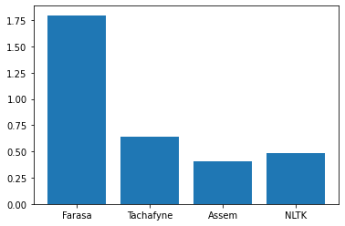

```python
plt.bar(['Farasa','Tachafyne','Assem','NLTK'],np.power(t_e,1/8))
```

تنبيه: قمنا بتطبيق عملية حسابية علي النواتج لتوضيح الصورة.

عام الأفضل من حيث السرعة.

و لكن هذه النصوص تعتبر قصيره كونه مصدرها تغريدات من تويتر, ماذا إذا كنا تعامل مع نصوص طويلة ؟

```python
large_data = ' '.join(list(data[:5000].tweet))
```

```python
len(large_data)
```

```
332267
```

```python
large_data[:1000]
```

```
'- رافق أولئك الأصدقاء . . الذين يدخلون حب الحيـاة داخل روحك ، من يثبتون لك أنك تستطيع الوقوف في كل مر ّ ة تتعثر ، من يأخذ … باليمين 😌 😌 💕 كفووك الطيب 😍 💕 💕 إذا صادفتك أزمة فليكن قلبك مطمئن بأن الله سيفرج الأزمة ويزيل الكرب لأنه رب العالمين ! ! 🙏 🏻 💕 - محمد الشعراوي كلي ندم اني ما حضرت الملتقى . . 💔…
```

```python
t_e=[]
for i in range(len(stemmers)):
    s=time.time()
    stemmers[i](large_data)
    e=time.time()
    t_e.append(e-s)
```

```
<BarContainer object of 4 artists>
```

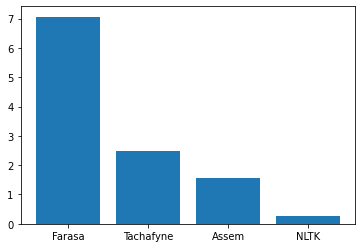

```python
plt.bar(['Farasa','Tachafyne','Assem','NLTK'],t_e)
```

مع زيادة حجم النص الواحد تقاربت السرعات نسبياً, كان أداء nltk أسرع من أداء عاصم, و لم تزل فراسة صاحبة المرتبة الأخيرة من حيص السرعة لكن أداء أفضل بكثير بالنسبة للنصوص الطويلة.

# الاستنتاج

بالطبع لم يمكن الحكم النهائي علي جودة الأدوات بهذه المعدودة, ة لكن يمكن يحدد كل مستخدم طبيعة الاختبار التي يراها مناسبة للتحديد.